# R Notebook

```r
library(magrittr)
library(dplyr)
```

```r
data_dir <- "/Users/benjaminsmith/Dropbox (University of Oregon)/UO-SAN Lab/Berkman Lab/Devaluation/analysis_files/data/"
```

```
There were 39 warnings (use warnings() to see them)
```

```r
preprocessed_data_filepath <- paste0(data_dir,"cloudresearch_survey_results/orfcs_preprocessed_anon_by_subj.csv")
library(readr)
library(ggplot2)
library(GGally)
preprocessed_data <- readr::read_csv(preprocessed_data_filepath)
```

```r
preprocessed_data$Gender <- factor(as.numeric(preprocessed_data$DEMO_5),levels=1:4,labels=c("Female","Male","Non-binary","Other"))
```

```
There were 13 warnings (use warnings() to see them)
```

```r
print(table(preprocessed_data$Gender))
```

```
    Female       Male Non-binary      Other
       531        243         13          1
```

```r
preprocessed_data$Gender3C <-preprocessed_data$Gender
preprocessed_data$Gender3C[preprocessed_data$Gender=="Non-binary"] <- "Other"
preprocessed_data$Gender3C <- as.factor(as.character(preprocessed_data$Gender3C))


preprocessed_data$RuralZIP <- as.factor(preprocessed_data$RuralZIP)
#race*ethnicity
#
#Categories will be "White Alone" "Hispanic White", "Other Hispanic", "Japanese"... and any group with 20
#apply(preprocessed_data[colnames(preprocessed_data)[grepl("DEMO_3b",colnames(preprocessed_data))]],2,table)
race_response_count <- rowSums(preprocessed_data[c("Demo_3a_IsHispanicLatinoSpanish",colnames(preprocessed_data)[grepl("DEMO_3b.*[^TEXT]$",colnames(preprocessed_data))])])
preprocessed_data$RaceCategorical <- ""
preprocessed_data$RaceCategorical[(race_response_count<=1) & (preprocessed_data$DEMO_3b_White==TRUE)] <- "WhiteOnly"
#preprocessed_data$RaceCategorical[(preprocessed_data$DEMO_3b_White==TRUE) & preprocessed_data$Demo_3a_IsHispanicLatinoSpanish & (race_response_count==2)] <- "WhiteHispanic"
#preprocessed_data$RaceCategorical[preprocessed_data$DEMO_3b_Japanese] <- "Japanese"
preprocessed_data$RaceCategorical[preprocessed_data$Demo_3a_IsHispanicLatinoSpanish] <- "HispanicAnyRace"
preprocessed_data$RaceCategorical[(
  preprocessed_data$DEMO_3b_Japanese |
  preprocessed_data$DEMO_3b_Chinese |
    preprocessed_data$DEMO_3b_Vietnamese |
    preprocessed_data$DEMO_3b_Filipino |
    preprocessed_data$DEMO_3b_Korean |
    preprocessed_data$`DEMO_3b_Asian Indian`
)] <- "Asian"
preprocessed_data$RaceCategorical[preprocessed_data$`DEMO_3b_Native Hawaiian` | preprocessed_data$DEMO_3b_Samoan | preprocessed_data$DEMO_3b_Chamorro] <- "HawaiianOtherPacificIslander"
preprocessed_data$RaceCategorical[preprocessed_data$RaceCategorical==""]<-"OtherRace"
preprocessed_data$RaceCategorical[race_response_count==0]<-"RaceNotReported"
#nb: "OtherHispanic" excludes respondents in "HawaiianOtherPacificIslander", and "Asian" Categories.
preprocessed_data$RaceCategorical <- factor(preprocessed_data$RaceCategorical,levels=c("WhiteOnly","Asian","HispanicAnyRace","HawaiianOtherPacificIslander","OtherRace","RaceNotReported"))


preprocessed_data$RuralZIP <- as.factor(preprocessed_data$RuralZIP)
```

reference for the analysis plan is at: https://osf.io/k7jav

From the analysis plan:

> People in more safer community environments and communities with healthier food environments (a) will have better eating behavior and (b) will be in better health, after controlling for perceived stress.

Let’s take a look at our distribution of eating behavior and health.

First, health outcome, as measured by BMI:

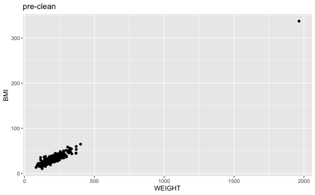

```r
ggplot(preprocessed_data,aes(WEIGHT, BMI))+geom_point()+labs(title="pre-clean")
```

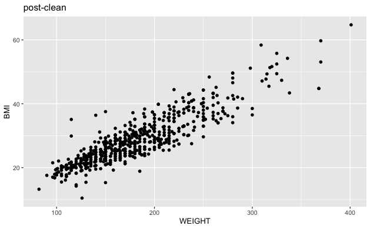

```r
#need to remove this one data point for data quality issue.
preprocessed_data[!is.na(preprocessed_data$WEIGHT) & preprocessed_data$WEIGHT>500,c("WEIGHT","WEIGHT_kg","BMI")] <- NA

ggplot(preprocessed_data,aes(WEIGHT, BMI))+geom_point()+labs(title="post-clean")
```

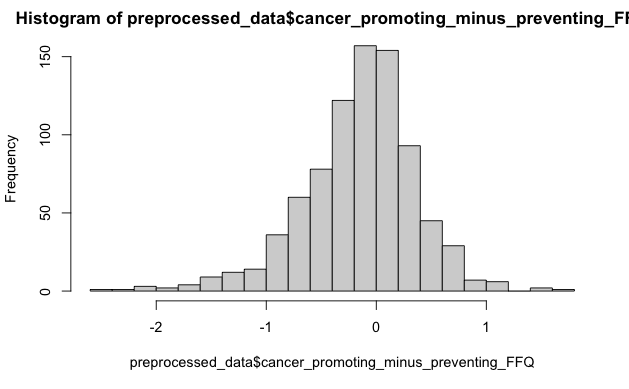

```r
hist(preprocessed_data$cancer_promoting_minus_preventing_FFQ,breaks = 20)
```

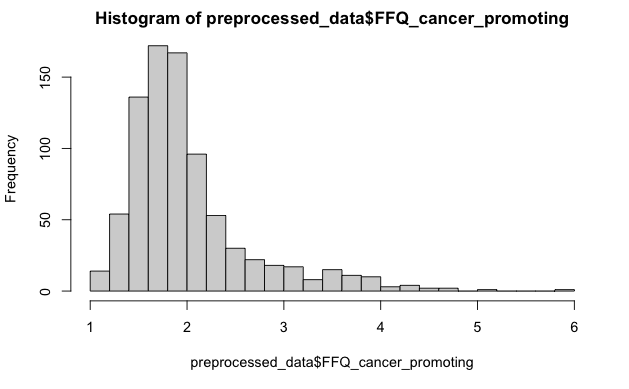

```r
hist(preprocessed_data$FFQ_cancer_promoting,breaks = 20)
```

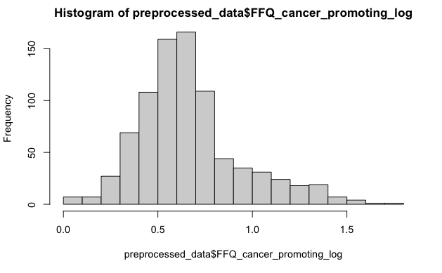

```r
#let's create a log measure of this because it is right-skewed
#though perhaps the danger is right-skewed as well? so I'm not sure.
preprocessed_data$FFQ_cancer_promoting_log <- log(preprocessed_data$FFQ_cancer_promoting)
preprocessed_data$FFQ_cancer_preventing_log <- log(preprocessed_data$FFQ_cancer_preventing)

hist(preprocessed_data$FFQ_cancer_promoting_log,breaks = 20)
```

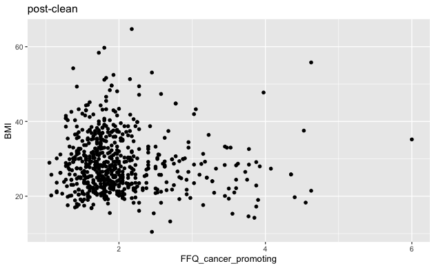

```r
ggplot(preprocessed_data,aes(FFQ_cancer_promoting, BMI))+geom_point()+labs(title="post-clean")
```

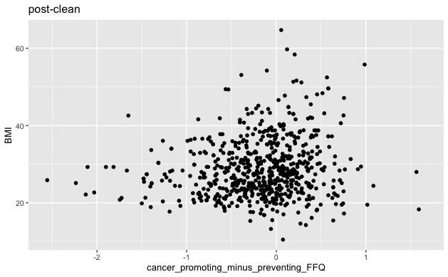

```r
ggplot(preprocessed_data,aes(cancer_promoting_minus_preventing_FFQ, BMI))+geom_point()+labs(title="post-clean")
```

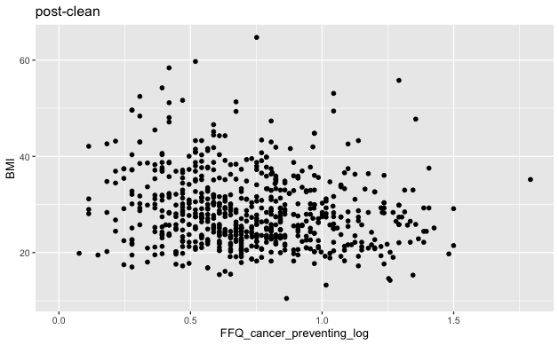

```r
ggplot(preprocessed_data,aes(FFQ_cancer_preventing_log, BMI))+geom_point()+labs(title="post-clean")
```

```r
cor.test(preprocessed_data$cancer_promoting_minus_preventing_FFQ,preprocessed_data$BMI)
```

```
    Pearson's product-moment correlation

data:  preprocessed_data$cancer_promoting_minus_preventing_FFQ and preprocessed_data$BMI
t = 3.3607, df = 662, p-value = 0.0008222
alternative hypothesis: true correlation is not equal to 0
95 percent confidence interval:
 0.05396212 0.20359687
sample estimates:
      cor
0.1295168
```

```r
cor.test(preprocessed_data$FFQ_cancer_promoting,preprocessed_data$BMI)
```

```
    Pearson's product-moment correlation

data:  preprocessed_data$FFQ_cancer_promoting and preprocessed_data$BMI
t = -1.3209, df = 662, p-value = 0.187
alternative hypothesis: true correlation is not equal to 0
95 percent confidence interval:
 -0.12686338  0.02491175
sample estimates:
        cor
-0.05127185
```

```r
cor.test(preprocessed_data$FFQ_cancer_preventing,preprocessed_data$BMI)
```

```
    Pearson's product-moment correlation

data:  preprocessed_data$FFQ_cancer_preventing and preprocessed_data$BMI
t = -3.9156, df = 662, p-value = 9.952e-05
alternative hypothesis: true correlation is not equal to 0
95 percent confidence interval:
 -0.22397532 -0.07522756
sample estimates:
       cor
-0.1504528
```

```r
cor.test(preprocessed_data$FFQ_cancer_preventing_log,preprocessed_data$BMI)
```

```
    Pearson's product-moment correlation

data:  preprocessed_data$FFQ_cancer_preventing_log and preprocessed_data$BMI
t = -4.3386, df = 662, p-value = 1.658e-05
alternative hypothesis: true correlation is not equal to 0
95 percent confidence interval:
 -0.23933539 -0.09134613
sample estimates:
       cor
-0.1662769
```

```r
custom_points <- function(...){
  ggally_points(...,alpha=0.2)
}
```

We should use cancer_preventing as our health behavior–it seems to relate most closely with BMI. That was a bit of a suprise but there you go!

Also–how many of the subcategories of cancer_promoting should we be looking at?

Now let’s look at perceived stress

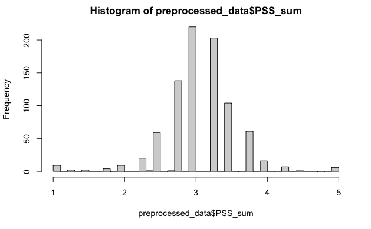

```r
hist(preprocessed_data$PSS_sum,breaks=30)
```

OK, now we look at the harder items: community safety and food access.

For food access, and community safety we have MESA:

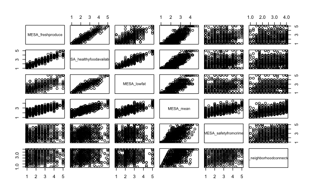

```r
#library("ggpairs")
pairs(preprocessed_data[c("MESA_freshproduce","MESA_healthyfoodavailability","MESA_lowfat","MESA_mean","MESA_safetyfromcrime", "MESA_neighborhoodconnectedness")])
```

> To measure the effect of community on eating behavior and health, we will use two linear models to predict (1) eating behavior and (2) health outcome from
> 1. Community healthy food environment
> 2. Community safety
> 3. self-report confounding variables PSS-4
> 4. demographic confounders relating to age and race

OK great, so now we have the ability to to all of that

```r
#need to tidy race a bit.

predict_bmi <- lm(BMI~
                    MESA_healthyfoodavailability+MESA_safetyfromcrime+PSS_sum+
                    DEMO_Age+Gender+RaceCategorical,
                  preprocessed_data)
summary(predict_bmi)
```

```
Call:
lm(formula = BMI ~ MESA_healthyfoodavailability + MESA_safetyfromcrime +
    PSS_sum + DEMO_Age + Gender + RaceCategorical, data = preprocessed_data)

Residuals:
    Min      1Q  Median      3Q     Max
-14.242  -5.411  -1.125   3.762  34.613

Coefficients:
                                             Estimate Std. Error t value Pr(>|t|)
(Intercept)                                 29.098282   2.222169  13.095  < 2e-16 ***
MESA_healthyfoodavailability                 0.752239   0.340728   2.208  0.02762 *
MESA_safetyfromcrime                         0.262359   0.304898   0.860  0.38985
PSS_sum                                     -0.814836   0.621326  -1.311  0.19019
DEMO_Age                                     0.003293   0.007528   0.437  0.66196
GenderMale                                   0.223158   0.655887   0.340  0.73379
GenderNon-binary                             4.782014   3.106948   1.539  0.12428
GenderOther                                 -6.762901   7.512245  -0.900  0.36833
RaceCategoricalAsian                        -0.501463   1.185550  -0.423  0.67246
RaceCategoricalHispanicAnyRace              -3.609322   1.277317  -2.826  0.00487 **
RaceCategoricalHawaiianOtherPacificIslander -0.425895   1.716155  -0.248  0.80409
RaceCategoricalOtherRace                    -3.251937   1.928196  -1.687  0.09219 .
RaceCategoricalRaceNotReported               0.539436   3.382151   0.159  0.87333
---
Signif. codes:  0 ‘***’ 0.001 ‘**’ 0.01 ‘*’ 0.05 ‘.’ 0.1 ‘ ’ 1

Residual standard error: 7.495 on 627 degrees of freedom
  (242 observations deleted due to missingness)
Multiple R-squared:  0.03754,   Adjusted R-squared:  0.01912
F-statistic: 2.038 on 12 and 627 DF,  p-value: 0.01923
```

```r
predict_ffq <- lm(cancer_promoting_minus_preventing_FFQ~
                    MESA_healthyfoodavailability+MESA_safetyfromcrime+PSS_sum+
                    DEMO_Age+Gender+RaceCategorical,
                  preprocessed_data)
summary(predict_ffq)
```

```
Call:
lm(formula = cancer_promoting_minus_preventing_FFQ ~ MESA_healthyfoodavailability +
    MESA_safetyfromcrime + PSS_sum + DEMO_Age + Gender + RaceCategorical,
    data = preprocessed_data)

Residuals:
     Min       1Q   Median       3Q      Max
-2.20162 -0.27230  0.06276  0.30915  1.74195

Coefficients:
                                              Estimate Std. Error t value Pr(>|t|)
(Intercept)                                 -0.1132923  0.1376193  -0.823  0.41064
MESA_healthyfoodavailability                 0.0698966  0.0214605   3.257  0.00118 **
MESA_safetyfromcrime                         0.0062599  0.0193595   0.323  0.74652
PSS_sum                                     -0.0491422  0.0376907  -1.304  0.19270
DEMO_Age                                    -0.0012930  0.0005074  -2.548  0.01103 *
GenderMale                                   0.0407697  0.0417553   0.976  0.32919
GenderNon-binary                            -0.1022937  0.1473694  -0.694  0.48782
GenderOther                                 -0.1520392  0.5162078  -0.295  0.76843
RaceCategoricalAsian                        -0.0897567  0.0754283  -1.190  0.23444
RaceCategoricalHispanicAnyRace               0.0982779  0.0784793   1.252  0.21087
RaceCategoricalHawaiianOtherPacificIslander -0.1015326  0.1076059  -0.944  0.34570
RaceCategoricalOtherRace                    -0.0853195  0.1243573  -0.686  0.49288
RaceCategoricalRaceNotReported              -0.0715121  0.2121146  -0.337  0.73611
---
Signif. codes:  0 ‘***’ 0.001 ‘**’ 0.01 ‘*’ 0.05 ‘.’ 0.1 ‘ ’ 1

Residual standard error: 0.5152 on 739 degrees of freedom
  (130 observations deleted due to missingness)
Multiple R-squared:  0.03486,   Adjusted R-squared:  0.01919
F-statistic: 2.224 on 12 and 739 DF,  p-value: 0.009423
```

> There is a rural-urban disparity in (a) eating behavior and (b) health outcomes in Oregon, after controlling for age and race but not income or SES.

```r
predict_ffq_rural <- lm(cancer_promoting_minus_preventing_FFQ~RuralZIP+
```

```
There were 13 warnings (use warnings() to see them)
```

```r
                    #MESA_healthyfoodavailability+MESA_safetyfromcrime+PSS_sum+
                    DEMO_Age+Gender+RaceCategorical,
                  preprocessed_data)
summary(predict_ffq_rural)
```

```
Call:
lm(formula = cancer_promoting_minus_preventing_FFQ ~ RuralZIP +
    DEMO_Age + Gender + RaceCategorical, data = preprocessed_data)

Residuals:
     Min       1Q   Median       3Q      Max
-2.25008 -0.27422  0.06421  0.32314  1.70305

Coefficients:
                                              Estimate Std. Error t value Pr(>|t|)
(Intercept)                                 -0.1054614  0.0390570  -2.700  0.00709 **
RuralZIPTRUE                                 0.0286925  0.0389546   0.737  0.46162
DEMO_Age                                    -0.0012951  0.0005089  -2.545  0.01114 *
GenderMale                                   0.0332378  0.0419539   0.792  0.42847
GenderNon-binary                            -0.0244841  0.1520210  -0.161  0.87209
GenderOther                                 -0.1355850  0.5180758  -0.262  0.79362
RaceCategoricalAsian                        -0.1119114  0.0762461  -1.468  0.14260
RaceCategoricalHispanicAnyRace               0.1016477  0.0792225   1.283  0.19987
RaceCategoricalHawaiianOtherPacificIslander -0.1054523  0.1081974  -0.975  0.33007
RaceCategoricalOtherRace                    -0.0921164  0.1272990  -0.724  0.46953
RaceCategoricalRaceNotReported              -0.0103183  0.2123496  -0.049  0.96126
---
Signif. codes:  0 ‘***’ 0.001 ‘**’ 0.01 ‘*’ 0.05 ‘.’ 0.1 ‘ ’ 1

Residual standard error: 0.517 on 733 degrees of freedom
  (138 observations deleted due to missingness)
Multiple R-squared:  0.01772,   Adjusted R-squared:  0.004317
F-statistic: 1.322 on 10 and 733 DF,  p-value: 0.214
```

```r
predict_bmi_rural <- lm(BMI~RuralZIP+
```

```
There were 50 or more warnings (use warnings() to see the first 50)
```

```r
                    #MESA_healthyfoodavailability+MESA_safetyfromcrime+PSS_sum+
                    DEMO_Age+Gender3C+RaceCategorical,
                  preprocessed_data)
summary(predict_bmi_rural)
```

```
Call:
lm(formula = BMI ~ RuralZIP + DEMO_Age + Gender3C + RaceCategorical,
    data = preprocessed_data)

Residuals:
    Min      1Q  Median      3Q     Max
-15.876  -5.395  -1.302   4.168  36.531

Coefficients:
                                             Estimate Std. Error t value Pr(>|t|)
(Intercept)                                 28.047519   0.592959  47.301  < 2e-16 ***
RuralZIP2                                    2.089661   0.613042   3.409 0.000695 ***
DEMO_Age                                     0.003377   0.007480   0.451 0.651812
Gender3CMale                                 0.423035   0.654626   0.646 0.518372
Gender3COther                                5.163172   3.078720   1.677 0.094033 .
RaceCategoricalAsian                        -0.647414   1.175332  -0.551 0.581944
RaceCategoricalHispanicAnyRace              -3.733464   1.283482  -2.909 0.003757 **
RaceCategoricalHawaiianOtherPacificIslander -0.302829   1.711195  -0.177 0.859590
RaceCategoricalOtherRace                    -3.752227   1.959148  -1.915 0.055919 .
RaceCategoricalRaceNotReported               0.948939   3.363304   0.282 0.777926
---
Signif. codes:  0 ‘***’ 0.001 ‘**’ 0.01 ‘*’ 0.05 ‘.’ 0.1 ‘ ’ 1

Residual standard error: 7.469 on 624 degrees of freedom
  (248 observations deleted due to missingness)
Multiple R-squared:  0.04009,   Adjusted R-squared:  0.02625
F-statistic: 2.896 on 9 and 624 DF,  p-value: 0.002307
```

> The rural-urban disparity can be partially explained by the availability of healthy food in the community.

```r
predict_bmi_rural_2 <- lm(BMI~RuralZIP+
                    MESA_healthyfoodavailability+
                    DEMO_Age+Gender+RaceCategorical,
                  preprocessed_data)
summary(predict_bmi_rural_2)
```

```
Call:
lm(formula = BMI ~ RuralZIP + MESA_healthyfoodavailability +
    DEMO_Age + Gender + RaceCategorical, data = preprocessed_data)

Residuals:
    Min      1Q  Median      3Q     Max
-17.886  -5.245  -1.131   4.448  35.838

Coefficients:
                                             Estimate Std. Error t value Pr(>|t|)
(Intercept)                                 26.698002   0.926888  28.804  < 2e-16 ***
RuralZIPTRUE                                 1.863278   0.618899   3.011  0.00271 **
MESA_healthyfoodavailability                 0.640455   0.331534   1.932  0.05384 .
DEMO_Age                                     0.003718   0.007460   0.498  0.61839
GenderMale                                   0.435971   0.652425   0.668  0.50423
GenderNon-binary                             7.244411   3.358460   2.157  0.03138 *
GenderOther                                 -5.883342   7.461939  -0.788  0.43074
RaceCategoricalAsian                        -0.466086   1.175242  -0.397  0.69181
RaceCategoricalHispanicAnyRace              -3.723564   1.280132  -2.909  0.00376 **
RaceCategoricalHawaiianOtherPacificIslander -0.242807   1.705747  -0.142  0.88685
RaceCategoricalOtherRace                    -3.714034   1.952590  -1.902  0.05762 .
RaceCategoricalRaceNotReported               0.529958   3.358618   0.158  0.87467
---
Signif. codes:  0 ‘***’ 0.001 ‘**’ 0.01 ‘*’ 0.05 ‘.’ 0.1 ‘ ’ 1

Residual standard error: 7.444 on 622 degrees of freedom
  (248 observations deleted due to missingness)
Multiple R-squared:  0.04974,   Adjusted R-squared:  0.03293
F-statistic: 2.959 on 11 and 622 DF,  p-value: 0.0007743
```

Need to follow this up with a full mediation model.

```r
#https://www.rdocumentation.org/packages/mediation/versions/4.5.0/topics/mediate
library(mediation)
#first need to only get rows that are NA on all the values; need to do this prior because we have two different models and need them using the same rows.
#strictly speaking, only need to add columns not included in both; lm package will consistently eliminate the rest.
exclude_row <- rowSums(is.na(preprocessed_data[,c("BMI","MESA_healthyfoodavailability")]))>0

preprocessed_data$MESA_healthyfoodavailability_ln <- log(preprocessed_data$MESA_healthyfoodavailability)
predict_mediator <- lm(MESA_healthyfoodavailability_ln~RuralZIP+DEMO_Age+Gender3C+RaceCategorical,preprocessed_data[!exclude_row,])
predict_outcome <- lm(BMI~MESA_healthyfoodavailability_ln+RuralZIP+DEMO_Age+Gender3C+RaceCategorical,preprocessed_data[!exclude_row,])

healthy_food_mediation <- mediate(predict_mediator,predict_outcome,boot=FALSE,sims=2000,treat="RuralZIP",mediator="MESA_healthyfoodavailability_ln")
```

```
treatment and control values do not match factor levels; using FALSE and TRUE as control and treatment, respectively
```

We didn’t pre-register taking the log of MESA_healthyfoodavailability, but it is a reasonable deviation considering its non-normality.

```r
summary(healthy_food_mediation)
```

```
Causal Mediation Analysis

Quasi-Bayesian Confidence Intervals

               Estimate 95% CI Lower 95% CI Upper p-value
ACME            0.17666      0.01517         0.40   0.027 *
ADE             1.92465      0.68489         3.11   0.003 **
Total Effect    2.10132      0.87723         3.32  <2e-16 ***
Prop. Mediated  0.07996      0.00694         0.26   0.027 *
---
Signif. codes:  0 ‘***’ 0.001 ‘**’ 0.01 ‘*’ 0.05 ‘.’ 0.1 ‘ ’ 1

Sample Size Used: 634


Simulations: 2000
```

There is a small mediation effect of healthy food availability, but we have to stress: it is *particularly* small.

And we couldn’t detect the effect from food consumption, which is a bit suspicious.

```
There were 13 warnings (use warnings() to see them)
```

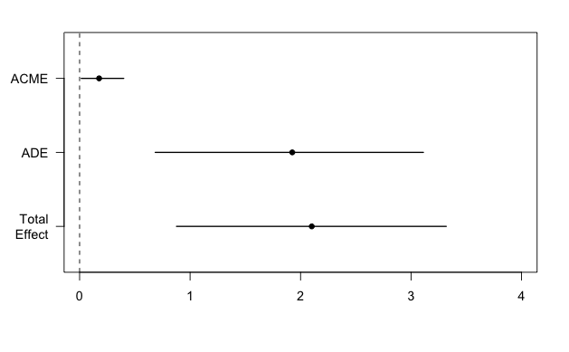

```r
plot(healthy_food_mediation)
```

> Eating behavior and health outcomes will be influenced by perceived stress (negatively), the Self Report Habit Index (negatively). Health outcomes will be influenced by the short version of the IPAQ (negatively)

```r
predict_health_outcomes <- lm(BMI~PSS_sum+SRHI_healthy+SRHI_unhealthy+IPAQ_total_METminutes,
                  preprocessed_data)
summary(predict_health_outcomes)
```

```
Call:
lm(formula = BMI ~ PSS_sum + SRHI_healthy + SRHI_unhealthy +
    IPAQ_total_METminutes, data = preprocessed_data)

Residuals:
    Min      1Q  Median      3Q     Max
-20.015  -4.712  -1.088   3.914  37.049

Coefficients:
                        Estimate Std. Error t value Pr(>|t|)
(Intercept)           32.2294387  2.3668666  13.617  < 2e-16 ***
PSS_sum               -0.6135643  0.6015653  -1.020  0.30813
SRHI_healthy          -0.1338435  0.0330823  -4.046 5.83e-05 ***
SRHI_unhealthy         0.0814629  0.0308489   2.641  0.00847 **
IPAQ_total_METminutes -0.0001329  0.0001031  -1.289  0.19769
---
Signif. codes:  0 ‘***’ 0.001 ‘**’ 0.01 ‘*’ 0.05 ‘.’ 0.1 ‘ ’ 1

Residual standard error: 7.348 on 659 degrees of freedom
  (218 observations deleted due to missingness)
Multiple R-squared:  0.07141,   Adjusted R-squared:  0.06577
F-statistic: 12.67 on 4 and 659 DF,  p-value: 6.138e-10
```

```r
predict_eating_behavior <- lm(cancer_promoting_minus_preventing_FFQ~PSS_sum+SRHI_healthy+SRHI_unhealthy+IPAQ_total_METminutes,
```

```
There were 13 warnings (use warnings() to see them)
```

```r
                  preprocessed_data)
summary(predict_eating_behavior)
```

```
Call:
lm(formula = cancer_promoting_minus_preventing_FFQ ~ PSS_sum +
    SRHI_healthy + SRHI_unhealthy + IPAQ_total_METminutes, data = preprocessed_data)

Residuals:
     Min       1Q   Median       3Q      Max
-2.04083 -0.24541  0.02776  0.27787  1.85396

Coefficients:
                        Estimate Std. Error t value Pr(>|t|)
(Intercept)            7.442e-02  1.253e-01   0.594   0.5528
PSS_sum               -6.393e-02  3.110e-02  -2.055   0.0402 *
SRHI_healthy          -1.742e-02  1.735e-03 -10.040   <2e-16 ***
SRHI_unhealthy         1.439e-02  1.634e-03   8.804   <2e-16 ***
IPAQ_total_METminutes  6.353e-06  4.877e-06   1.303   0.1930
---
Signif. codes:  0 ‘***’ 0.001 ‘**’ 0.01 ‘*’ 0.05 ‘.’ 0.1 ‘ ’ 1

Residual standard error: 0.4416 on 831 degrees of freedom
  (46 observations deleted due to missingness)
Multiple R-squared:  0.2855,    Adjusted R-squared:  0.282
F-statistic:    83 on 4 and 831 DF,  p-value: < 2.2e-16
```

> To measure the rural-urban disparity, we will use a similar linear model without community information but including rurality.

> We will then examine whether Community healthy food environment and Community safety mediate the rurality effect.

```r
#https://www.rdocumentation.org/packages/mediation/versions/4.5.0/topics/mediate
```

```
There were 13 warnings (use warnings() to see them)
```

```r
library(mediation)
#first need to only get rows that are NA on all the values; need to do this prior because we have two different models and need them using the same rows.
#strictly speaking, only need to add columns not included in both; lm package will consistently eliminate the rest.
exclude_row <- rowSums(is.na(preprocessed_data[,c("BMI","MESA_safetyfromcrime")]))>0
preprocessed_data$RuralZIP<-as.numeric(preprocessed_data$RuralZIP)

preprocessed_data$MESA_safetyfromcrime_ln <- log(preprocessed_data$MESA_safetyfromcrime)
predict_mediator <- lm(MESA_safetyfromcrime_ln~RuralZIP+DEMO_Age+Gender3C+RaceCategorical,preprocessed_data[!exclude_row,])
predict_outcome <- lm(BMI~MESA_safetyfromcrime_ln+RuralZIP+DEMO_Age+Gender3C+RaceCategorical,preprocessed_data[!exclude_row,])

crime_mediation <- mediate(predict_mediator,predict_outcome,boot=FALSE,sims=2000,treat="RuralZIP",mediator="MESA_safetyfromcrime_ln")
```

```r
summary(crime_mediation)
```

```
Causal Mediation Analysis

Quasi-Bayesian Confidence Intervals

               Estimate 95% CI Lower 95% CI Upper p-value
ACME            -0.1688      -0.4062         0.02   0.080 .
ADE              2.2536       1.0371         3.45  <2e-16 ***
Total Effect     2.0848       0.8532         3.28   0.001 ***
Prop. Mediated  -0.0771      -0.2815         0.01   0.081 .
---
Signif. codes:  0 ‘***’ 0.001 ‘**’ 0.01 ‘*’ 0.05 ‘.’ 0.1 ‘ ’ 1

Sample Size Used: 634


Simulations: 2000
```

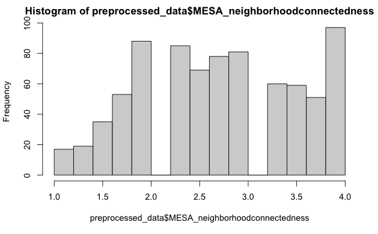

```r
hist(preprocessed_data$MESA_neighborhoodconnectedness)
```

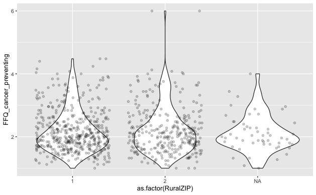

```r
ggplot(preprocessed_data,aes(x=as.factor(RuralZIP),y=FFQ_cancer_preventing))+geom_violin()+geom_jitter(alpha=0.2)
```

```r
summary(lm(cancer_promoting_minus_preventing_FFQ~RuralZIP,preprocessed_data %>% filter(!is.na(RuralZIP) & !is.na(cancer_promoting_minus_preventing_FFQ))))
```

```
Call:
lm(formula = cancer_promoting_minus_preventing_FFQ ~ RuralZIP,
    data = preprocessed_data %>% filter(!is.na(RuralZIP) & !is.na(cancer_promoting_minus_preventing_FFQ)))

Residuals:
     Min       1Q   Median       3Q      Max
-2.39041 -0.25994  0.06921  0.31459  1.72767

Coefficients:
            Estimate Std. Error t value Pr(>|t|)
(Intercept) -0.18772    0.05601  -3.352 0.000842 ***
RuralZIP     0.02313    0.03759   0.615 0.538515
---
Signif. codes:  0 ‘***’ 0.001 ‘**’ 0.01 ‘*’ 0.05 ‘.’ 0.1 ‘ ’ 1

Residual standard error: 0.5164 on 780 degrees of freedom
Multiple R-squared:  0.0004852, Adjusted R-squared:  -0.0007962
F-statistic: 0.3786 on 1 and 780 DF,  p-value: 0.5385
```

```r
summary(lm(cancer_promoting_minus_preventing_FFQ~RuralZIP,preprocessed_data))
```

```
Call:
lm(formula = cancer_promoting_minus_preventing_FFQ ~ RuralZIP,
    data = preprocessed_data)

Residuals:
     Min       1Q   Median       3Q      Max
-2.39041 -0.25994  0.06921  0.31459  1.72767

Coefficients:
            Estimate Std. Error t value Pr(>|t|)
(Intercept) -0.18772    0.05601  -3.352 0.000842 ***
RuralZIP     0.02313    0.03759   0.615 0.538515
---
Signif. codes:  0 ‘***’ 0.001 ‘**’ 0.01 ‘*’ 0.05 ‘.’ 0.1 ‘ ’ 1

Residual standard error: 0.5164 on 780 degrees of freedom
  (100 observations deleted due to missingness)
Multiple R-squared:  0.0004852, Adjusted R-squared:  -0.0007962
F-statistic: 0.3786 on 1 and 780 DF,  p-value: 0.5385
```

```r
summary(lm(cancer_promoting_minus_preventing_FFQ~RuralZIP+DEMO_Age+Gender3C+RaceCategorical,preprocessed_data))
```

```
Call:
lm(formula = cancer_promoting_minus_preventing_FFQ ~ RuralZIP +
    DEMO_Age + Gender3C + RaceCategorical, data = preprocessed_data)

Residuals:
     Min       1Q   Median       3Q      Max
-2.25003 -0.27408  0.06412  0.32370  1.70316

Coefficients:
                                              Estimate Std. Error t value Pr(>|t|)
(Intercept)                                 -0.1345492  0.0661680  -2.033   0.0424 *
RuralZIP                                     0.0288789  0.0389188   0.742   0.4583
DEMO_Age                                    -0.0012934  0.0005085  -2.543   0.0112 *
Gender3CMale                                 0.0332493  0.0419265   0.793   0.4280
Gender3COther                               -0.0330720  0.1461125  -0.226   0.8210
RaceCategoricalAsian                        -0.1118633  0.0761959  -1.468   0.1425
RaceCategoricalHispanicAnyRace               0.1022593  0.0791154   1.293   0.1966
RaceCategoricalHawaiianOtherPacificIslander -0.1053509  0.1081257  -0.974   0.3302
RaceCategoricalOtherRace                    -0.0920421  0.1272155  -0.724   0.4696
RaceCategoricalRaceNotReported              -0.0102498  0.2122108  -0.048   0.9615
---
Signif. codes:  0 ‘***’ 0.001 ‘**’ 0.01 ‘*’ 0.05 ‘.’ 0.1 ‘ ’ 1

Residual standard error: 0.5166 on 734 degrees of freedom
  (138 observations deleted due to missingness)
Multiple R-squared:  0.01766,   Adjusted R-squared:  0.005616
F-statistic: 1.466 on 9 and 734 DF,  p-value: 0.1563
```

```r
summary(lm(cancer_promoting_minus_preventing_FFQ~RuralZIP+DEMO_Age+Gender3C+RaceCategorical,preprocessed_data))
```

```
Call:
lm(formula = cancer_promoting_minus_preventing_FFQ ~ RuralZIP +
    DEMO_Age + Gender3C + RaceCategorical, data = preprocessed_data)

Residuals:
     Min       1Q   Median       3Q      Max
-2.25003 -0.27408  0.06412  0.32370  1.70316

Coefficients:
                                              Estimate Std. Error t value Pr(>|t|)
(Intercept)                                 -0.1345492  0.0661680  -2.033   0.0424 *
RuralZIP                                     0.0288789  0.0389188   0.742   0.4583
DEMO_Age                                    -0.0012934  0.0005085  -2.543   0.0112 *
Gender3CMale                                 0.0332493  0.0419265   0.793   0.4280
Gender3COther                               -0.0330720  0.1461125  -0.226   0.8210
RaceCategoricalAsian                        -0.1118633  0.0761959  -1.468   0.1425
RaceCategoricalHispanicAnyRace               0.1022593  0.0791154   1.293   0.1966
RaceCategoricalHawaiianOtherPacificIslander -0.1053509  0.1081257  -0.974   0.3302
RaceCategoricalOtherRace                    -0.0920421  0.1272155  -0.724   0.4696
RaceCategoricalRaceNotReported              -0.0102498  0.2122108  -0.048   0.9615
---
Signif. codes:  0 ‘***’ 0.001 ‘**’ 0.01 ‘*’ 0.05 ‘.’ 0.1 ‘ ’ 1

Residual standard error: 0.5166 on 734 degrees of freedom
  (138 observations deleted due to missingness)
Multiple R-squared:  0.01766,   Adjusted R-squared:  0.005616
F-statistic: 1.466 on 9 and 734 DF,  p-value: 0.1563
```

```r
summary(lm(BMI~MESA_neighborhoodconnectedness+RuralZIP+DEMO_Age+Gender3C+RaceCategorical,preprocessed_data))
```

```
Call:
lm(formula = BMI ~ MESA_neighborhoodconnectedness + RuralZIP +
    DEMO_Age + Gender3C + RaceCategorical, data = preprocessed_data)

Residuals:
    Min      1Q  Median      3Q     Max
-15.469  -5.339  -1.275   4.262  36.230

Coefficients:
                                             Estimate Std. Error t value Pr(>|t|)
(Intercept)                                 24.596378   1.466590  16.771  < 2e-16 ***
MESA_neighborhoodconnectedness               0.463974   0.359318   1.291 0.197091
RuralZIP                                     2.130139   0.613515   3.472 0.000552 ***
DEMO_Age                                     0.003345   0.007476   0.447 0.654718
Gender3CMale                                 0.532683   0.659763   0.807 0.419753
Gender3COther                                5.109563   3.077355   1.660 0.097342 .
RaceCategoricalAsian                        -0.710771   1.175729  -0.605 0.545707
RaceCategoricalHispanicAnyRace              -3.721550   1.282830  -2.901 0.003850 **
RaceCategoricalHawaiianOtherPacificIslander -0.270018   1.710469  -0.158 0.874617
RaceCategoricalOtherRace                    -3.753067   1.958102  -1.917 0.055735 .
RaceCategoricalRaceNotReported               1.145451   3.364950   0.340 0.733665
---
Signif. codes:  0 ‘***’ 0.001 ‘**’ 0.01 ‘*’ 0.05 ‘.’ 0.1 ‘ ’ 1

Residual standard error: 7.465 on 623 degrees of freedom
  (248 observations deleted due to missingness)
Multiple R-squared:  0.04266,   Adjusted R-squared:  0.02729
F-statistic: 2.776 on 10 and 623 DF,  p-value: 0.002307
```

```r
summary(lm(cancer_promoting_minus_preventing_FFQ~MESA_neighborhoodconnectedness+RuralZIP+DEMO_Age+Gender3C+RaceCategorical,preprocessed_data))
```

```
Call:
lm(formula = cancer_promoting_minus_preventing_FFQ ~ MESA_neighborhoodconnectedness +
    RuralZIP + DEMO_Age + Gender3C + RaceCategorical, data = preprocessed_data)

Residuals:
     Min       1Q   Median       3Q      Max
-2.23588 -0.27512  0.06902  0.31449  1.75899

Coefficients:
                                              Estimate Std. Error t value Pr(>|t|)
(Intercept)                                 -0.3272748  0.0943535  -3.469 0.000554 ***
MESA_neighborhoodconnectedness               0.0658014  0.0230722   2.852 0.004467 **
RuralZIP                                     0.0343534  0.0387785   0.886 0.375969
DEMO_Age                                    -0.0012830  0.0005061  -2.535 0.011448 *
Gender3CMale                                 0.0489698  0.0420868   1.164 0.244988
Gender3COther                               -0.0258278  0.1454298  -0.178 0.859089
RaceCategoricalAsian                        -0.1204122  0.0758876  -1.587 0.113008
RaceCategoricalHispanicAnyRace               0.1004693  0.0787362   1.276 0.202351
RaceCategoricalHawaiianOtherPacificIslander -0.0982498  0.1076328  -0.913 0.361635
RaceCategoricalOtherRace                    -0.0972747  0.1266150  -0.768 0.442573
RaceCategoricalRaceNotReported               0.0133445  0.2113489   0.063 0.949673
---
Signif. codes:  0 ‘***’ 0.001 ‘**’ 0.01 ‘*’ 0.05 ‘.’ 0.1 ‘ ’ 1

Residual standard error: 0.5141 on 733 degrees of freedom
  (138 observations deleted due to missingness)
Multiple R-squared:  0.02844,   Adjusted R-squared:  0.01519
F-statistic: 2.146 on 10 and 733 DF,  p-value: 0.01932
```

```r
#https://www.rdocumentation.org/packages/mediation/versions/4.5.0/topics/mediate
```

```
There were 13 warnings (use warnings() to see them)
```

```r
library(mediation)
#first need to only get rows that are NA on all the values; need to do this prior because we have two different models and need them using the same rows.
#strictly speaking, only need to add columns not included in both; lm package will consistently eliminate the rest.
exclude_row <- rowSums(is.na(preprocessed_data[,c("FFQ_cancer_preventing","MESA_neighborhoodconnectedness")]))>0
preprocessed_data$RuralZIP<-as.numeric(preprocessed_data$RuralZIP)


predict_mediator <- lm(MESA_neighborhoodconnectedness~RuralZIP+DEMO_Age+Gender3C+RaceCategorical,preprocessed_data[!exclude_row,])
predict_outcome <- lm(FFQ_cancer_preventing~MESA_neighborhoodconnectedness+RuralZIP+DEMO_Age+Gender3C+RaceCategorical,preprocessed_data[!exclude_row,])

connectedness_mediation <- mediate(predict_mediator,predict_outcome,boot=FALSE,sims=2000,treat="RuralZIP",mediator="MESA_neighborhoodconnectedness")
```

```r
summary(connectedness_mediation)
```

```
Causal Mediation Analysis

Quasi-Bayesian Confidence Intervals

               Estimate 95% CI Lower 95% CI Upper p-value
ACME            0.01936     -0.00812         0.05    0.17
ADE            -0.01415     -0.10954         0.08    0.80
Total Effect    0.00521     -0.09543         0.10    0.90
Prop. Mediated  0.15663     -5.40836         7.77    0.84

Sample Size Used: 744


Simulations: 2000
```

> We will measure two-way correlations between eating behavior, health outcomes, PSS-4, the SRHI, and the IPAQ.

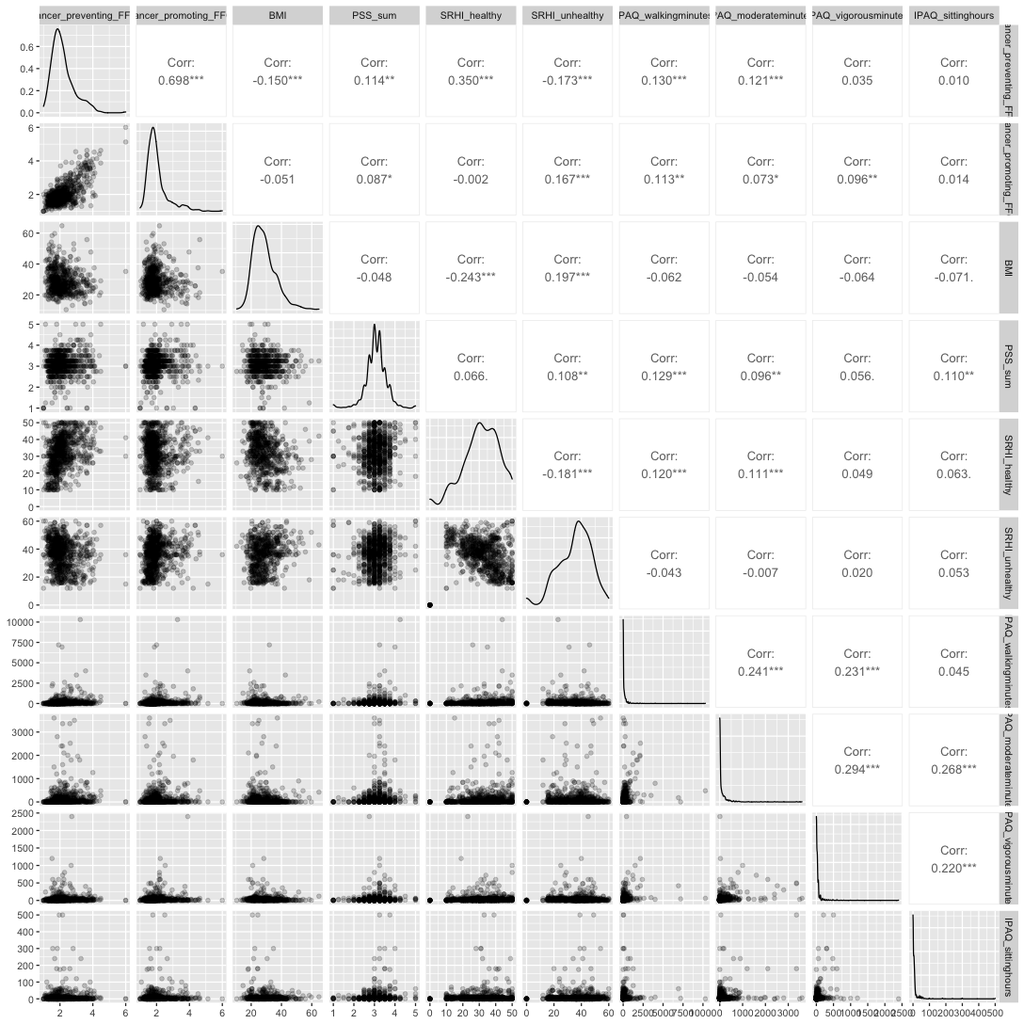

```r
ggpairs(preprocessed_data[c("cancer_preventing_FFQ","cancer_promoting_FFQ","BMI","PSS_sum","SRHI_healthy","SRHI_unhealthy","IPAQ_walkingminutes","IPAQ_moderateminutes","IPAQ_vigorousminutes","IPAQ_sittinghours")],
        progress = FALSE
        ,lower = list(continuous = custom_points))
```

### Conclusions re: pre-registered analyses.

### General hypotheses on factors afecting eatint behavior and health outcomes.

We hypothesized that people in safer [H1a] and more heathily provisioned [H1b] communities will have better eating behavior.

Following a pre-registered analysis plan, we found that people scoring higher on MESA healthy food availability reported WORSE eating behavior - higher amounts of cancer promoting relative to preventing foods on the FFQ (beta=0.070, p=0.001). **probably suggests MESA food availability is wrongly reverse-scored!?!?!** Community safety was unrelated

We also hypothesized that people in safer [H2a] and more healthily provisioned [H2b] communities will have lower BMIs.

## Explaining the rural-urban disparity.

We predicted disparities could be explained by the availability of healthy food in the community (H4). We didn’t test mediation effect of eating behavior because the main effect was not significant.

Confirmation here was marginal; a model predicting BMI from Rurality and healthy food availability found healthy food availability marginally predicted BMI ($p=0.05$). A mediation analysis found the proportion of the effect of rurality on BMI mediated by healthy food availability to be just 8.0% (CI=[0.7%, 26%], $p=0.03$).

## Supplementary predictions

We predicted that perceived stress (measured by the 4-item PSS) and the SRHI would negatively affect eating behavior and health outcomes.

Partially confirming the hypothesis, in a linear model of BMI, healthy (p<0.001) and unhealthy (p<0.01) components of the SRHI strongly affected the health outcome, but PSS did not significantly affect the health outcome.

In a linear model of unhealthy food consumption, contrary to our hypothesis, PSS *negatively* predicted unhealthy eating (p<0.05) suggesting that respondents reporting higher stress ate more healthily. Consistent with our hypothesis, healthy (p<0.001) and unhealthy (p<0.001) componetns of the SRHI strongly affected the measure of eating behavior.

Overall, the link between SHRI and BMI confirms the role of SHRI in health outcomes. More examination is needed into the role of stress in healthy eating.

We also predicted that IPAQ–a measure of exercise– would be affected by health outcomes, though not eating behavior